# Simulated Data Analyzed with PCA and PLS-DA

Eric R Scott

Right now the way I’m simulating data might not be terribly realistic. There is one chunk of variables with no covariance (that’s ok); another chunk covaries with eachother, but not with the grouping variable (also imaginable); the third chunk of variables also covary within each group, but not neccesariliy with the grouping variable. Instead, I’ve just changed the means (intercepts?) of the variables for each group.

Maybe this is why PLS-DA is doing a poor job relative to PERMANOVA, and this data might not be terribly realistic (plot discriminating variables vs. group membership? vs one discriminating variable, color = group membership?).

Another possibility would be to create three chunks again±—–one that doesn’t covary, one that covaries, and a third that covaries. Then take that third chunk, pick one of the variables and make it the Y variable. Then I could use that for regression PLS. *Or* I could take that Y variable, `arrange(Y)`, and then assign groups such that rows with high values for Y are group A and those with low values of Y are group B. Then all the other discriminating variables should co-vary with group membership and distinguish between groups becasue they were all set up to covary with Y. This might be a more realistic dataset? It might also be a situation where PLS-DA performs better than PERMANOVA.

# Overview

After discussion with Elizabeth we decided to create the following combination of datasets:

1. Without signal (no covariance) and without discriminating variables. We would predict poor PCA and no separation by PLS-DA
2. With signal (covariance) and without discriminating variables. We would expect good PCA (high % var explained), but no separation in PCA or PLS-DA
3. Without signal (covariance) and **with** discriminating variables. We would expect poor PCA, but significant PLS-DA
4. With signal **and** discriminating variables. We would expect good PCA, but little separation in PCA space if only a few discriminating variables, but significant PLS-DA.

I am consider making a Shiny app that allows you to tweak the parameters that generate the data and plots PCA and PLS-DA side-by-side.

*Permutation testing:* What about using each of these 4 parameter combinations to create ~100 randomly generated datasets. Then with each, I could do PCA followed by t-tests on the PC axes vs. PLS-DA to demonstrate which is better at detecting real separation in the data. Maybe the cherry-picked figure is enough, but this would only be a few sentences in the manuscript and would be valuable I think.

To-Do: Add MANNOVA or PERMANOVA to this

# Setup

## Load Packages

```r
# Required Packages
library(MASS)
library(tidyverse)
library(ropls)
library(chemhelper)
#chemhelper contains custom functions for interfacing with ropls package in a friendlier way (and other things).
#Install with devtools::install_github("Aariq/chemhelper")
library(cowplot) #for making and saving prettier plots
library(broom) #for tidy(), which turns model output into dataframes
library(vegan) #for PERMANOVA
```

## Create Custom Plotting Functions

```r
# Functions for plotting
library(latex2exp)
pca_plot <- function(pca.opls, group_var){
  plotdata <- chemhelper::get_plotdata(pca.opls)
  ggplot(plotdata$plot_data, aes(x = p1, y = p2, color = group_var)) +
    geom_point() +
    stat_ellipse() +
    labs(x = paste0("PC1 (", plotdata$var_explained$R2X[1] * 100, "%)"),
         y = paste0("PC2 (", plotdata$var_explained$R2X[2] * 100, "%)")) +
    scale_colour_discrete("Group Membership") +
    theme_bw() +
    ggtitle("PCA") +
    labs(caption = TeX(
      paste0(nrow(plotdata$var_explained), " principal components;",
             "$R^2(cumulative) = ", max(plotdata$var_explained$`R2X(cum)`, "$"))))
}
plsda_plot <- function(plsda.opls){
  plotdata <- chemhelper::get_plotdata(plsda.opls)
  ggplot(plotdata$plot_data, aes(x = p1, y = p2, color = y1)) +
    geom_point() +
    stat_ellipse() +
    labs(x = paste0("P1 (", plotdata$axis_stats$R2X[1] * 100, "%)"),
         y = paste0("P2 (", plotdata$axis_stats$R2X[2] * 100, "%)")) +
    scale_color_discrete("Group Membership") +
    theme_bw() +
    ggtitle("PLS-DA") +
    labs(caption = TeX(
      paste0("$R^{2}_{Y} = ", plotdata$model_stats$`R2Y(cum)`, "$; ",
             "$Q^{2} = ", plotdata$model_stats$`Q2(cum)`, "$; ",
             "$p_{Q^{2}} = ", plotdata$model_stats$pQ2, "$")))
}
oplsda_plot <- function(oplsda.opls){
  plotdata <- chemhelper::get_plotdata(oplsda.opls)
  ggplot(plotdata$plot_data, aes(x = p1, y = o1, color = y1)) +
    geom_point() +
    stat_ellipse() +
    labs(x = paste0("Pred (", plotdata$axis_stats$R2X[1] * 100, "%)"),
         y = paste0("Ortho (", plotdata$axis_stats$R2X[2] * 100, "%)")) +
    scale_color_discrete("Group Membership") +
    theme_bw() +
    ggtitle("OPLS-DA") +
    labs(caption = TeX(
      paste0("$R^{2}_{Y}=", plotdata$model_stats$`R2Y(cum)`, "$; ",
             "$Q^{2}=", plotdata$model_stats$`Q2(cum)`, "$; ",
             "$p_{Q^{2}}=", plotdata$model_stats$pQ2, "$")))
}
```

## Create Custom Summary Table Function

```r
my_table <- function(data, pca, plsda){
  VIPs <- get_VIP(plsda)

  loadings_pls <- getLoadingMN(plsda) %>%
    as.data.frame() %>%
    rownames_to_column(var = "Variable") %>%
    rename(p1_loading = p1, p2_loading = p2)

  loadings_pca <- getLoadingMN(pca) %>%
    as.data.frame() %>%
    rownames_to_column(var = "Variable") %>%
    select(Variable, PC1_loading = p1, PC2_loading = p2)

  t_tests <- data %>%
    select(-group) %>%
    map_df(~t.test(.~data$group)$p.value) %>%
    gather(key = Variable, value = t_test_p.value)

  join1 <- full_join(VIPs, loadings_pls)
  join2 <- full_join(join1, loadings_pca)
  join3 <- full_join(join2, t_tests)
  return(join3)
}
```

## Create Function to Generate Data

This code chunk creates the function `sim.vcov()` which generates a dataset where we can tune signal, noise, discriminating variables, strength of signal, and strength of discriminating variables. I’m using the notation `n` for number of observations and `p` for number of variables. `sim.vcov()` requires the following arguments:

*Note: I took a slightly different approach. Instead of creating one variance-covariance matrix for the whole dataset, I generate each type of variable (noise, signal, discriminating) separately and bind the columns together.*

```r
sim.vcov <- function(p_noise,
                     p_signal,
                     p_disc,
                     cov_signal,
                     cov_disc = 0,
                     diff_disc,
                     var = 0.5,
                     N,
                     seed = NA){
  # Choose a random number for seed if none is supplied
  if(is.na(seed)){
    seed = as.integer(runif(1) * 10e6)
  }
  # make noise data
  if(p_noise > 0){
  S_noise <- matrix(rep(0.05, p_noise^2), ncol = p_noise)
  diag(S_noise) <- var
  set.seed(seed)
  data_noise <- mvrnorm(n = N, Sigma = S_noise, mu = rep(0, p_noise)) %>%
    as.data.frame()
  colnames(data_noise) <- paste0("noise_", 1:p_noise)
  } else {data_noise <- list()}

  # make signal data
  if(p_signal > 0){
    S_signal <- matrix(rep(cov_signal, p_signal^2), ncol = p_signal)
    diag(S_signal) <- var
    set.seed(seed)
    data_signal <- mvrnorm(n = N, Sigma = S_signal, mu = rep(0, p_signal)) %>%
      as.data.frame()
    colnames(data_signal) <- paste0("signal_", 1:p_signal)
  } else {data_signal <- list()}

  # make discriminating data
  if(p_disc > 0){
  S_disc <- matrix(rep(cov_disc, p_disc^2), ncol = p_disc)
  diag(S_disc) <- var

  # make data for group A
  set.seed(seed)
  means_A <- rep((diff_disc/2), p_disc)
  data_A <- mvrnorm(n = N/2, mu = means_A, Sigma = S_disc) %>%
    as.data.frame()

  # make data for group B
  set.seed(seed+1)
  means_B <- rep(-1*(diff_disc/2), p_disc)
  data_B <- mvrnorm(n = N/2, mu = means_B, Sigma = S_disc) %>%
    as.data.frame()

  data_disc <- bind_rows(data_A, data_B)
  colnames(data_disc) <- paste0("disc_", 1:p_disc)
  } else{data_disc <- list()}

  # column bind it all together
  sim.data <- bind_cols(data_disc, data_signal, data_noise) %>%
    add_column(group = rep(c("a","b"), each = N/2), .before = 1)

  return(sim.data)
}
```

# Create safe version of opls()

Occasionally I was getting ‘matrix is singular’ type errors from `opls()`, which I think is just a chance occurrance with the random data. This “safe” version will always return `NULL` when there is any kind of error.

```r
safe.opls <- possibly(opls, otherwise = NULL)
```

# Set global options (needle in haystack scenario)

I’ll set a few global options here to make it easier to play around with the simulation.

```r
N = 20 #total number of observations
P = 60 #total number of variables
signal.prop = 0.25 #when there is signal, what proportion of variables are signal
cov_signal = 0.25 #covariance for signal variables
disc.prop = 0.5 #when there are discriminating variables, what proportion
diff_disc = 1 #mean difference between groups for discriminating variables
nperm = 100 #how many perumutations
seed = 100 #seed
#calculated values
p_signal = round(P*signal.prop)
p_disc = round(P*disc.prop)
```

# 1. No Covariance, No Discrimination

## Generate data

```r
sim.data1 <- sim.vcov(p_noise = P,
                      p_signal = 0,
                      p_disc = 0,
                      cov_signal = 0,
                      diff_disc = 0,
                      N = N,
                      seed = seed)
```

## PCA & PLS-DA

### Run PCA

```r
sim.pca1 <- opls(select(sim.data1, -group), plotL = FALSE)
```

```
PCA
20 samples x 60 variables
standard scaling of predictors
      R2X(cum) pre ort
Total    0.537   6   0
```

### Run PLS-DA

```r
sim.plsda1 <- try(opls(select(sim.data1, -group), sim.data1$group,
                  plotL = FALSE))
```

```
Error : No model was built because the first predictive component was already not significant;
Select a number of predictive components of 1 if you want the algorithm to compute a model despite this.
```

This fails, but I’ll force two axes for the sake of plotting.

```r
## Must force axes
sim.plsda1 <- opls(select(sim.data1, -group), sim.data1$group,
                   predI = 2,
                   permI = 200,
                   plotL = FALSE)
```

```
PLS-DA
20 samples x 60 variables and 1 response
standard scaling of predictors and response(s)
      R2X(cum) R2Y(cum) Q2(cum) RMSEE pre ort pR2Y   pQ2
Total    0.175    0.902  -0.232  0.17   2   0 0.82 0.495
```

## Plots:

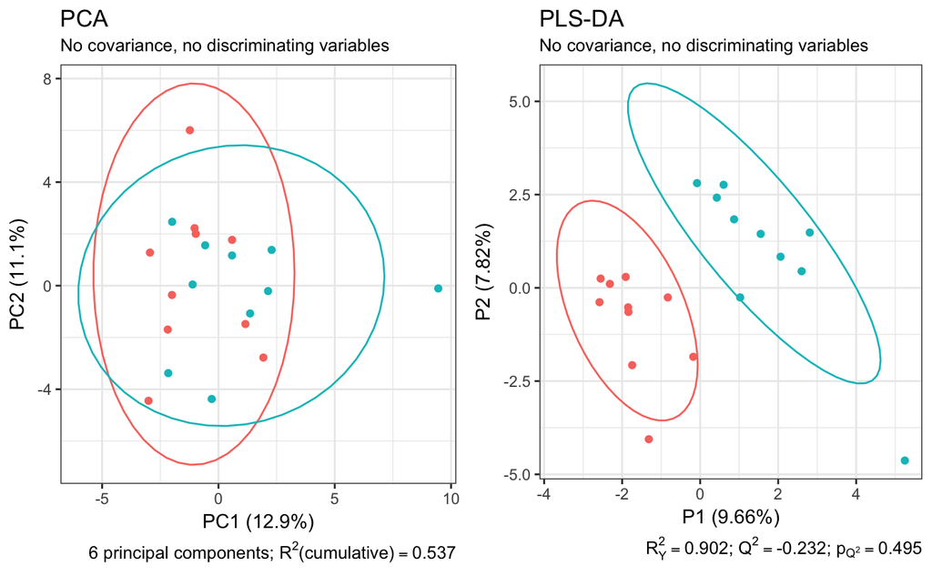

```r
p1 <- plot_grid(pca_plot(sim.pca1, sim.data1$group) +
                 theme(legend.position = "none") +
                 ggtitle("PCA", subtitle = "No covariance, no discriminating variables"),
               plsda_plot(sim.plsda1) +
                 theme(legend.position = "none") +
                 ggtitle("PLS-DA", subtitle = "No covariance, no discriminating variables"))
p1
```

## Get PC axis loadings and VIP scores.

Note: It’s probably not very responsible to look at VIP scores from a PLS-DA model that is not significant

```r
my_table(sim.data1, sim.pca1, sim.plsda1) %>% arrange(desc(VIP))
```

| Variable | VIP | p1_loading | p2_loading | PC1_loading | PC2_loading | t_test_p.value |
| --- | --- | --- | --- | --- | --- | --- |
| noise_32 | 2.3454231 | -0.321706409 | -0.096197623 | -0.152364658 | -0.0999295814 | 0.004634498 |
| noise_11 | 1.8708242 | -0.231337602 | -0.135460835 | -0.068548287 | 0.0062112765 | 0.032106488 |
| noise_24 | 1.8149896 | -0.244592951 | -0.071635699 | -0.083086795 | 0.1203754040 | 0.036638588 |
| noise_9 | 1.7180051 | -0.287832561 | 0.136919968 | -0.267354383 | -0.0435096241 | 0.055600005 |
| noise_47 | 1.6289175 | -0.267442072 | 0.106289913 | -0.206266441 | 0.0708646447 | 0.065021432 |
| noise_7 | 1.5734290 | -0.254174568 | 0.059660301 | -0.180028202 | -0.0064194524 | 0.075530380 |
| noise_55 | 1.4550860 | 0.099986451 | 0.203413535 | -0.082339489 | -0.2346976141 | 0.145890051 |
| noise_5 | 1.4471240 | -0.136847103 | -0.021241921 | -0.115417508 | -0.1448453854 | 0.127037482 |
| noise_41 | 1.4326533 | -0.234006618 | 0.033929100 | -0.119747370 | 0.1811439424 | 0.115791460 |
| noise_22 | 1.4115626 | -0.225667241 | 0.040255247 | -0.160389790 | -0.1127098108 | 0.117951632 |

[output cut: 50 more lines]

## Permutation testing

First, make a bunch of datasets with the same parameters

```r
sim.data1.list <- map(1:nperm,
    ~sim.vcov(p_noise = P,
              p_signal = 0,
              p_disc = 0,
              cov_signal = 0,
              diff_disc = 0,
              N = N,
              seed = NA))
names(sim.data1.list) <- 1:nperm
```

Now, do PCA on all of them and get scores

Now do t-tests on all of them along PCs 1 and 2 and get p-values

```r
#The 'group' variable is the same in all datasets.
grouping <- sim.data1.list[[1]]$group
p1.testresults <- scores.data1.list %>%
  #maps t.test() function to all dataframes and converts output into dataframe with tidy()
  map_dfr(~t.test(.$p1 ~ grouping) %>% tidy(), .id = "dataset") %>%
  #selects just columns of interest
  select(dataset,
         PC1.effect.size = "estimate",
         PC1.t = "statistic",
         PC1.p.value = "p.value")
p2.testresults <- scores.data1.list %>%
  map_dfr(~t.test(.$p2 ~ grouping) %>% tidy(), .id = "dataset") %>%
  select(dataset,
         PC2.effect.size = "estimate",
         PC2.t = "statistic",
         PC2.p.value = "p.value")
data1.PCAresults <- bind_cols(p1.testresults, p2.testresults)
```

And do PERMANOVA on all of them

```r
data1.permanova <- map_dbl(sim.data1.list,
    ~ adonis(select(., -group) ~ grouping, method = "eu")$aov.tab$`Pr(>F)`[1])
```

Now do PLS-DA on all of them and get p-values (this will take a long time)

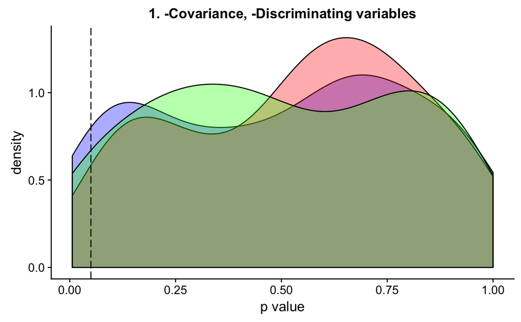

```r
data1.PLSresults <- pls.data1.list %>%
  map_dfr(~get_plotdata(.)$model_stats, .id = "dataset")
data1.comparison <- full_join(data1.PCAresults, data1.PLSresults) %>% add_column("permanova" = data1.permanova)
p1.perm <- ggplot(data1.comparison) +
  geom_density(aes(PC1.p.value), fill = "blue", alpha = 0.33) +
  geom_density(aes(pQ2), fill = "red", alpha = 0.33) +
  geom_density(aes(permanova), fill = "green", alpha = 0.33) +
  labs(x = "p value") +
  geom_vline(xintercept = 0.05, linetype = 5) +
  ggtitle("1. -Covariance, -Discriminating variables")
p1.perm
```

# 2. Yes Covariance, No Discrimination

## Generate Data:

```r
set.seed(100)
sim.data2 <- sim.vcov(p_noise = P - p_signal,
                      p_signal = p_signal,
                      p_disc = 0,
                      cov_signal = cov_signal,
                      diff_disc = 0,
                      N = N,
                      seed = seed)
```

## PCA & PLS-DA

### Run PCA

```r
sim.pca2 <- opls(select(sim.data2, -group), plotL = FALSE)
```

```
PCA
20 samples x 60 variables
standard scaling of predictors
      R2X(cum) pre ort
Total    0.574   5   0
```

### Run PLS-DA

```r
sim.plsda2 <- try(opls(select(sim.data2, -group), sim.data2$group,
                  plotL = FALSE))
```

```
Error : No model was built because the first predictive component was already not significant;
Select a number of predictive components of 1 if you want the algorithm to compute a model despite this.
```

This fails, but I’ll force two axes for the sake of plotting.

```r
## Must force axes
sim.plsda2 <- opls(select(sim.data2, -group), sim.data2$group,
                   predI = 2,
                   permI = 200, plotL = FALSE)
```

```
PLS-DA
20 samples x 60 variables and 1 response
standard scaling of predictors and response(s)
      R2X(cum) R2Y(cum) Q2(cum) RMSEE pre ort pR2Y   pQ2
Total    0.243    0.798  -0.255 0.244   2   0 0.76 0.595
```

### Plots:

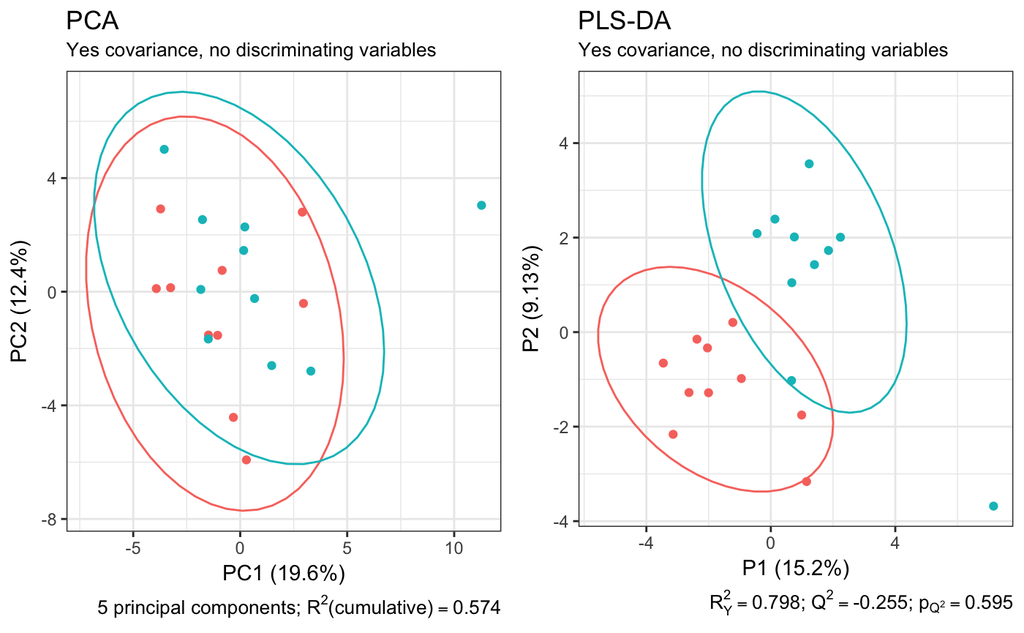

```r
p2 <- plot_grid(pca_plot(sim.pca2, sim.data2$group) +
                 theme(legend.position = "none") +
                 ggtitle("PCA", subtitle = "Yes covariance, no discriminating variables"),
               plsda_plot(sim.plsda2) +
                 theme(legend.position = "none") +
                 ggtitle("PLS-DA", subtitle = "Yes covariance, no discriminating variables"))
p2
```

PC1 slightly better, but overall R^2 the same. PLS-DA still not significant

## Get PC axis loadings and VIP scores.

Note: It’s probably not responsible to look at VIP scores from a PLS-DA model that is not significant

```r
my_table(sim.data2, sim.pca2, sim.plsda2) %>% arrange(desc(VIP))
```

| Variable | VIP | p1_loading | p2_loading | PC1_loading | PC2_loading | t_test_p.value |
| --- | --- | --- | --- | --- | --- | --- |
| noise_31 | 1.8737570 | -0.16078846 | -0.2140601768 | -0.007308417 | -0.135434037 | 0.04055299 |
| noise_17 | 1.7163558 | -0.27583491 | -0.0143965015 | -0.124410127 | -0.211649342 | 0.03327318 |
| noise_23 | 1.6315649 | -0.16023027 | 0.1152246192 | -0.194643845 | 0.168162216 | 0.07301270 |
| signal_13 | 1.5237801 | -0.31096211 | 0.1663752634 | -0.240842903 | -0.057931037 | 0.07195928 |
| noise_1 | 1.4947518 | 0.04360786 | 0.2692204555 | -0.088613945 | 0.148142667 | 0.19269790 |
| noise_34 | 1.4828464 | 0.18558194 | 0.1462167969 | 0.034962505 | 0.171010383 | 0.08332563 |
| signal_8 | 1.4660477 | -0.24112370 | 0.2038497657 | -0.180009729 | -0.127723169 | 0.81239661 |
| noise_30 | 1.4608384 | -0.32295194 | 0.1120043635 | -0.210259105 | -0.127572040 | 0.12129107 |
| noise_21 | 1.3716375 | -0.16460306 | 0.1761769296 | -0.111897142 | -0.171751956 | 0.84808771 |
| signal_3 | 1.3224799 | 0.20125954 | 0.1599875240 | 0.010738926 | 0.264915136 | 0.11267802 |

[output cut: 50 more lines]

## Permutation testing

First, make a bunch of datasets with the same parameters

```r
sim.data2.list <- map(1:nperm,
                      ~sim.vcov(p_noise = P - p_signal,
                                p_signal = p_signal,
                                p_disc = 0,
                                cov_signal = cov_signal,
                                diff_disc = 0,
                                N = N,
                                seed = NA))
names(sim.data2.list) <- 1:nperm
```

Now, do PCA on all of them and get loadings.

Now do t-tests on all of them along PCs 1 and 2 and get p-values

```r
#The 'group' variable is the same in all datasets.
grouping <- sim.data2.list[[1]]$group
p1.testresults <- scores.data2.list %>%
  #maps t.test() function to all dataframes and converts output into dataframe with tidy()
  map_dfr(~t.test(.$p1~grouping) %>% tidy(), .id = "dataset") %>%
  #selects just columns of interest
  select(dataset,
         PC1.effect.size = "estimate",
         PC1.t = "statistic",
         PC1.p.value = "p.value")
p2.testresults <- scores.data2.list %>%
  map_dfr(~t.test(.$p2~grouping) %>% tidy(), .id = "dataset") %>%
  select(dataset,
         PC2.effect.size = "estimate",
         PC2.t = "statistic",
         PC2.p.value = "p.value")
data2.PCAresults <- bind_cols(p1.testresults, p2.testresults)
```

And do PERMANOVA on all of them

```r
data2.permanova <- map_dbl(sim.data2.list,
    ~ adonis(select(., -group) ~ grouping, method = "eu")$aov.tab$`Pr(>F)`[1])
```

Now do PLS-DA on all of them and get p-values (this will take a long time)

```r
data2.PLSresults <- pls.data2.list %>% map_dfr(~get_plotdata(.)$model_stats, .id = "dataset")
data2.PLSresults
```

| dataset | R2X(cum) | R2Y(cum) | Q2(cum) | RMSEE | pre | ort | pR2Y | pQ2 |
| --- | --- | --- | --- | --- | --- | --- | --- | --- |
| 1 | 0.304 | 0.908 | -0.45600 | 0.164 | 2 | 0 | 0.070 | 0.725 |
| 2 | 0.311 | 0.830 | 0.05990 | 0.224 | 2 | 0 | 0.500 | 0.350 |
| 3 | 0.319 | 0.848 | 0.11200 | 0.212 | 2 | 0 | 0.295 | 0.385 |
| 4 | 0.227 | 0.890 | -0.00865 | 0.180 | 2 | 0 | 0.230 | 0.230 |
| 5 | 0.264 | 0.892 | -0.09390 | 0.178 | 2 | 0 | 0.245 | 0.525 |
| 6 | 0.275 | 0.768 | -1.69000 | 0.261 | 2 | 0 | 0.805 | 0.930 |
| 7 | 0.342 | 0.870 | 0.40800 | 0.195 | 2 | 0 | 0.280 | 0.160 |
| 8 | 0.300 | 0.809 | -1.32000 | 0.237 | 2 | 0 | 0.400 | 0.985 |
| 9 | 0.261 | 0.711 | -0.78100 | 0.291 | 2 | 0 | 0.985 | 0.785 |
| 10 | 0.275 | 0.751 | -0.31100 | 0.271 | 2 | 0 | 0.845 | 0.570 |

[output cut: 90 more lines]

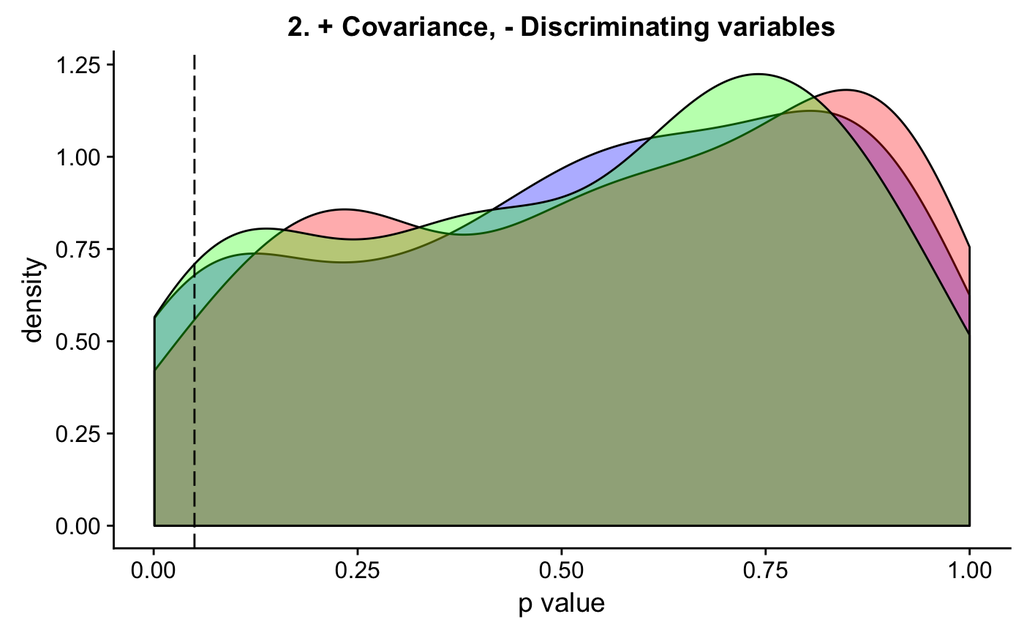

```r
data2.comparison <- full_join(data2.PCAresults, data2.PLSresults) %>%
  add_column("permanova" = data2.permanova)
p2.perm <- ggplot(data2.comparison) +
  geom_density(aes(PC1.p.value), fill = "blue", alpha = 0.33) +
  geom_density(aes(pQ2), fill = "red", alpha = 0.33) +
  geom_density(aes(permanova), fill = "green", alpha = 0.33) +
  labs(x = "p value") +
  geom_vline(xintercept = 0.05, linetype = 5) +
  ggtitle("2. + Covariance, - Discriminating variables")
p2.perm
```

# 3. No Covariance, Yes Discrimination

## Generate Data:

```r
set.seed(100)
sim.data3 <- sim.vcov(p_noise = P - p_disc,
                      p_signal = 0,
                      p_disc = p_disc,
                      cov_signal = cov_signal,
                      diff_disc = diff_disc,
                      N = N,
                      seed = seed)
```

## PCA & PLS-DA

### Run PCA

```r
sim.pca3 <- opls(select(sim.data3, -group), plotL = FALSE)
```

```
PCA
20 samples x 60 variables
standard scaling of predictors
      R2X(cum) pre ort
Total    0.559   5   0
```

### Run PLS-DA

```r
sim.plsda3 <- opls(select(sim.data3, -group), sim.data3$group,
                   permI = 200,
                   plotL = FALSE)
```

```
PLS-DA
20 samples x 60 variables and 1 response
standard scaling of predictors and response(s)
      R2X(cum) R2Y(cum) Q2(cum) RMSEE pre ort  pR2Y   pQ2
Total    0.233    0.953   0.898 0.114   1   0 0.005 0.005
```

Single component model only, so force two axes for the sake of plotting:

```r
sim.plsda3 <- opls(select(sim.data3, -group), sim.data3$group,
                   permI = 200,
                   predI = 2,
                   plotL = FALSE)
```

```
PLS-DA
20 samples x 60 variables and 1 response
standard scaling of predictors and response(s)
      R2X(cum) R2Y(cum) Q2(cum)  RMSEE pre ort  pR2Y   pQ2
Total    0.284    0.991   0.868 0.0519   2   0 0.005 0.005
```

### Plots:

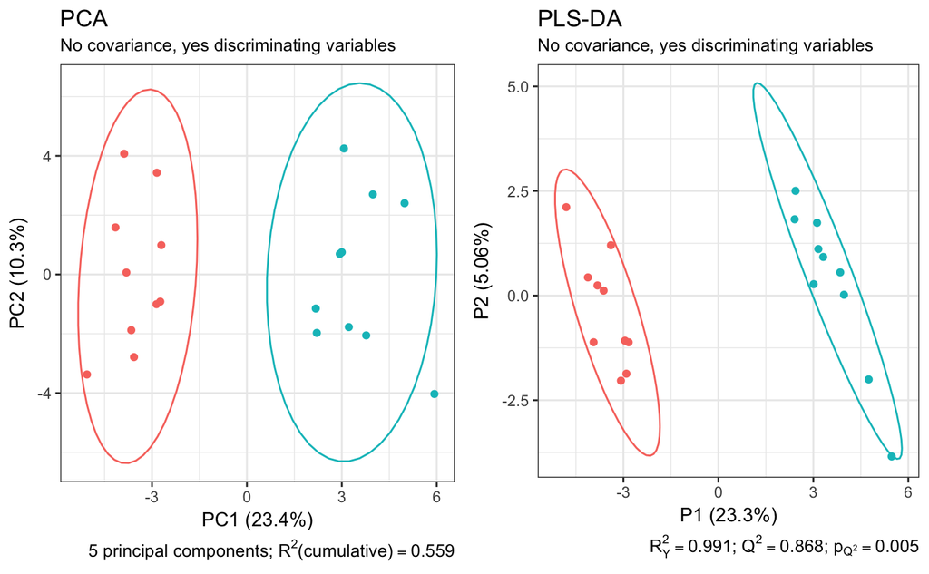

```r
p3 <- plot_grid(pca_plot(sim.pca3, sim.data3$group) +
                 theme(legend.position = "none") +
                 ggtitle("PCA", subtitle = "No covariance, yes discriminating variables"),
               plsda_plot(sim.plsda3) +
                 theme(legend.position = "none") +
                 ggtitle("PLS-DA", subtitle = "No covariance, yes discriminating variables"))
p3
```

## Get PC axis loadings and VIP scores.

```r
my_table(sim.data3, sim.pca3, sim.plsda3) %>% arrange(desc(VIP))
```

| Variable | VIP | p1_loading | p2_loading | PC1_loading | PC2_loading | t_test_p.value |
| --- | --- | --- | --- | --- | --- | --- |
| disc_14 | 1.7328844 | -0.218558436 | -0.087711168 | -0.215284148 | 0.134938787 | 1.998829e-05 |
| disc_2 | 1.7255225 | -0.224743403 | -0.010251787 | -0.223354920 | -0.087599430 | 4.875691e-05 |
| disc_24 | 1.6365939 | -0.212231827 | -0.101908587 | -0.208434039 | 0.021806496 | 7.977361e-05 |
| disc_29 | 1.5954059 | -0.211238899 | 0.018875218 | -0.210480915 | -0.029141945 | 9.269368e-05 |
| disc_30 | 1.5196361 | -0.195333011 | -0.054344627 | -0.192684575 | 0.054261022 | 2.820883e-04 |
| disc_18 | 1.5172315 | -0.210574989 | 0.081945392 | -0.210669531 | 0.065688184 | 4.175352e-04 |
| disc_15 | 1.4466283 | -0.198518200 | 0.107910205 | -0.199534992 | -0.065088428 | 1.439512e-03 |
| disc_28 | 1.4344816 | -0.192545614 | 0.028905767 | -0.191768774 | -0.052287850 | 8.799400e-04 |
| disc_19 | 1.4312886 | -0.169155683 | -0.140688970 | -0.165369921 | -0.132863996 | 1.140979e-03 |
| disc_3 | 1.4261173 | -0.179267602 | -0.098808425 | -0.176086375 | 0.133368496 | 1.114428e-03 |

[output cut: 50 more lines]

## Permutation testing

First, make a bunch of datasets with the same parameters

```r
sim.data3.list <- map(1:nperm,
                      ~sim.vcov(p_noise = P - p_disc,
                                p_signal = 0,
                                p_disc = p_disc,
                                cov_signal = 0,
                                diff_disc = diff_disc,
                                N = N,
                                seed = NA))
```

Now, do PCA on all of them and get loadings.

Now do t-tests on all of them along PCs 1 and 2 and get p-values

```r
#The 'group' variable is the same in all datasets.
grouping <- sim.data3.list[[1]]$group
p1.testresults <- scores.data3.list %>%
  #maps t.test() function to all dataframes and converts output into dataframe with tidy()
  map_dfr(~t.test(.$p1~grouping) %>% tidy(), .id = "dataset") %>%
  #selects just columns of interest
  select(dataset,
         PC1.effect.size = "estimate",
         PC1.t = "statistic",
         PC1.p.value = "p.value")
p2.testresults <- scores.data3.list %>%
  map_dfr(~t.test(.$p2~grouping) %>% tidy(), .id = "dataset") %>%
  select(dataset,
         PC2.effect.size = "estimate",
         PC2.t = "statistic",
         PC2.p.value = "p.value")
data3.PCAresults <- bind_cols(p1.testresults, p2.testresults)
```

And do PERMANOVA on all of them

```r
data3.permanova <- map_dbl(sim.data3.list,
    ~ adonis(select(., -group) ~ grouping, method = "eu")$aov.tab$`Pr(>F)`[1])
```

Now do PLS-DA on all of them and get p-values (this will take a long time)

```r
data3.PLSresults <- pls.data3.list %>% map_dfr(~get_plotdata(.)$model_stats, .id = "dataset")
data3.PLSresults
```

| dataset | R2X(cum) | R2Y(cum) | Q2(cum) | RMSEE | pre | ort | pR2Y | pQ2 |
| --- | --- | --- | --- | --- | --- | --- | --- | --- |
| 1 | 0.314 | 0.983 | 0.886 | 0.0709 | 2 | 0 | 0.005 | 0.005 |
| 2 | 0.277 | 0.980 | 0.803 | 0.0769 | 2 | 0 | 0.005 | 0.005 |
| 3 | 0.264 | 0.990 | 0.845 | 0.0556 | 2 | 0 | 0.005 | 0.005 |
| 4 | 0.289 | 0.986 | 0.848 | 0.0636 | 2 | 0 | 0.005 | 0.005 |
| 5 | 0.265 | 0.984 | 0.829 | 0.0681 | 2 | 0 | 0.005 | 0.005 |
| 6 | 0.341 | 0.990 | 0.932 | 0.0539 | 2 | 0 | 0.005 | 0.005 |
| 7 | 0.291 | 0.993 | 0.923 | 0.0456 | 2 | 0 | 0.005 | 0.005 |
| 8 | 0.304 | 0.985 | 0.835 | 0.0674 | 2 | 0 | 0.005 | 0.005 |
| 9 | 0.307 | 0.993 | 0.899 | 0.0464 | 2 | 0 | 0.005 | 0.005 |
| 10 | 0.331 | 0.983 | 0.911 | 0.0700 | 2 | 0 | 0.005 | 0.005 |

[output cut: 90 more lines]

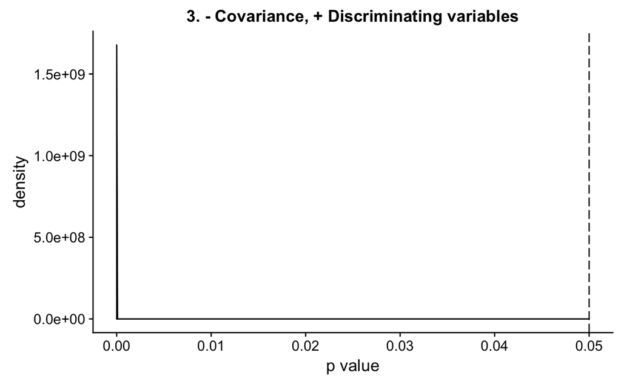

```r
data3.comparison <- full_join(data3.PCAresults, data3.PLSresults) %>% add_column("permanova" = data3.permanova)
p3.perm <- ggplot(data3.comparison) +
  geom_density(aes(PC1.p.value), fill = "blue", alpha = 0.33) +
  geom_density(aes(pQ2), fill = "red", alpha = 0.33) +
  geom_density(aes(permanova), fill = "green", alpha = 0.33) +
  labs(x = "p value") +
  geom_vline(xintercept = 0.05, linetype = 5) +
  ggtitle("3. - Covariance, + Discriminating variables")
p3.perm
```

# 4. Yes Covariance, Yes Discrimination

## Generate Data:

```r
sim.data4 <- sim.vcov(p_noise = P - p_signal - p_disc,
                      p_signal = p_signal,
                      p_disc = p_disc,
                      cov_signal = cov_signal,
                      diff_disc = diff_disc,
                      N = N,
                      seed = seed)
```

## PCA & PLS-DA

### Run PCA

```r
sim.pca4 <- opls(select(sim.data4, -group), plotL = FALSE)
```

```
PCA
20 samples x 60 variables
standard scaling of predictors
      R2X(cum) pre ort
Total    0.572   4   0
```

### Run PLS-DA

```r
sim.plsda4 <- opls(select(sim.data4, -group), sim.data4$group,
                   permI = 200,
                   plotL = FALSE)
```

```
PLS-DA
20 samples x 60 variables and 1 response
standard scaling of predictors and response(s)
      R2X(cum) R2Y(cum) Q2(cum)  RMSEE pre ort  pR2Y   pQ2
Total    0.362    0.974   0.889 0.0869   2   0 0.005 0.005
```

```r
sim.plsda4 <- opls(select(sim.data4, -group), sim.data4$group,
                   permI = 200,
                   predI = 2,
                   plotL = FALSE)
```

```
PLS-DA
20 samples x 60 variables and 1 response
standard scaling of predictors and response(s)
      R2X(cum) R2Y(cum) Q2(cum)  RMSEE pre ort  pR2Y   pQ2
Total    0.362    0.974   0.889 0.0869   2   0 0.005 0.005
```

### Plots:

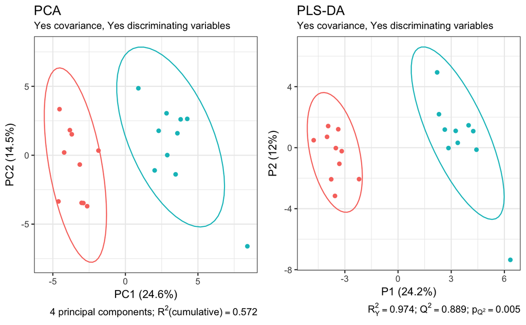

```r
p4 <- plot_grid(pca_plot(sim.pca4, sim.data4$group) +
                 theme(legend.position = "none") +
                 ggtitle("PCA", subtitle = "Yes covariance, Yes discriminating variables"),
               plsda_plot(sim.plsda4) +
                 theme(legend.position = "none") +
                 ggtitle("PLS-DA", subtitle = "Yes covariance, Yes discriminating variables"))
p4
```

## Get PC axis loadings and VIP scores.

```r
my_table(sim.data4, sim.pca4, sim.plsda4) %>% arrange(desc(VIP))
```

| Variable | VIP | p1_loading | p2_loading | PC1_loading | PC2_loading | t_test_p.value |
| --- | --- | --- | --- | --- | --- | --- |
| disc_2 | 1.72083080 | -0.215247826 | -0.086631619 | -0.197791085 | -1.181972e-01 | 4.875691e-05 |
| disc_14 | 1.71848307 | -0.221097445 | 0.020417693 | -0.219255498 | 2.537731e-02 | 1.998829e-05 |
| disc_24 | 1.62894056 | -0.207983712 | -0.090116716 | -0.189717716 | -1.198204e-01 | 7.977361e-05 |
| disc_29 | 1.58696289 | -0.210992674 | 0.016951785 | -0.205932634 | -3.854514e-02 | 9.269368e-05 |
| disc_30 | 1.51370788 | -0.189714994 | -0.070138979 | -0.175208987 | -8.944595e-02 | 2.820883e-04 |
| disc_18 | 1.50073829 | -0.210278508 | 0.020302199 | -0.203717640 | -5.455971e-02 | 4.175352e-04 |
| disc_15 | 1.43033320 | -0.190645020 | -0.053514423 | -0.176009561 | -1.187605e-01 | 1.439512e-03 |
| disc_28 | 1.42985948 | -0.178199832 | -0.127231375 | -0.157372423 | -1.219696e-01 | 8.799400e-04 |
| disc_19 | 1.41827176 | -0.163852261 | -0.104679934 | -0.147183071 | -1.107987e-01 | 1.140979e-03 |
| disc_3 | 1.41582937 | -0.178061369 | -0.008350314 | -0.174983306 | 2.521867e-02 | 1.114428e-03 |

[output cut: 50 more lines]

## Permutation testing

First, make a bunch of datasets with the same parameters

```r
sim.data4.list <- map(1:nperm,
                      ~sim.vcov(p_noise = P - p_signal - p_disc,
                                p_signal = p_signal,
                                p_disc = p_disc,
                                cov_signal = cov_signal,
                                diff_disc = diff_disc,
                                N = N,
                                seed = NA)) %>%
  set_names(1:nperm)
```

Now, do PCA on all of them and get loadings.

Now do t-tests on all of them along PCs 1 and 2 and get p-values

```r
#The 'group' variable is the same in all datasets.
grouping <- sim.data4.list[[1]]$group
p1.testresults <- scores.data4.list %>%
  #maps t.test() function to all dataframes and converts output into dataframe with tidy()
  map_dfr(~t.test(.$p1~grouping) %>% tidy(), .id = "dataset") %>%
  #selects just columns of interest
  select(dataset,
         PC1.effect.size = "estimate",
         PC1.t = "statistic",
         PC1.p.value = "p.value")
p2.testresults <- scores.data4.list %>%
  map_dfr(~t.test(.$p2~grouping) %>% tidy(), .id = "dataset") %>%
  select(dataset,
         PC2.effect.size = "estimate",
         PC2.t = "statistic",
         PC2.p.value = "p.value")
data4.PCAresults <- bind_cols(p1.testresults, p2.testresults)
```

And do PERMANOVA on all of them

```r
data4.permanova <- map_dbl(sim.data4.list,
    ~ adonis(select(., -group) ~ grouping, method = "eu")$aov.tab$`Pr(>F)`[1])
```

Now do PLS-DA on all of them and get p-values (this will take a long time)

```r
data4.PLSresults <- pls.data4.list %>% map_dfr(~get_plotdata(.)$model_stats, .id = "dataset")
data4.PLSresults
```

| dataset | R2X(cum) | R2Y(cum) | Q2(cum) | RMSEE | pre | ort | pR2Y | pQ2 |
| --- | --- | --- | --- | --- | --- | --- | --- | --- |
| 1 | 0.434 | 0.965 | 0.912 | 0.1010 | 2 | 0 | 0.005 | 0.005 |
| 2 | 0.361 | 0.970 | 0.862 | 0.0933 | 2 | 0 | 0.005 | 0.005 |
| 3 | 0.409 | 0.971 | 0.883 | 0.0927 | 2 | 0 | 0.005 | 0.005 |
| 4 | 0.376 | 0.954 | 0.817 | 0.1170 | 2 | 0 | 0.005 | 0.005 |
| 5 | 0.306 | 0.964 | 0.769 | 0.1030 | 2 | 0 | 0.005 | 0.005 |
| 6 | 0.466 | 0.975 | 0.931 | 0.0857 | 2 | 0 | 0.005 | 0.005 |
| 7 | 0.413 | 0.972 | 0.924 | 0.0915 | 2 | 0 | 0.005 | 0.005 |
| 8 | 0.398 | 0.959 | 0.839 | 0.1100 | 2 | 0 | 0.005 | 0.005 |
| 9 | 0.307 | 0.985 | 0.847 | 0.0654 | 2 | 0 | 0.005 | 0.005 |
| 10 | 0.431 | 0.968 | 0.903 | 0.0976 | 2 | 0 | 0.005 | 0.005 |

[output cut: 90 more lines]

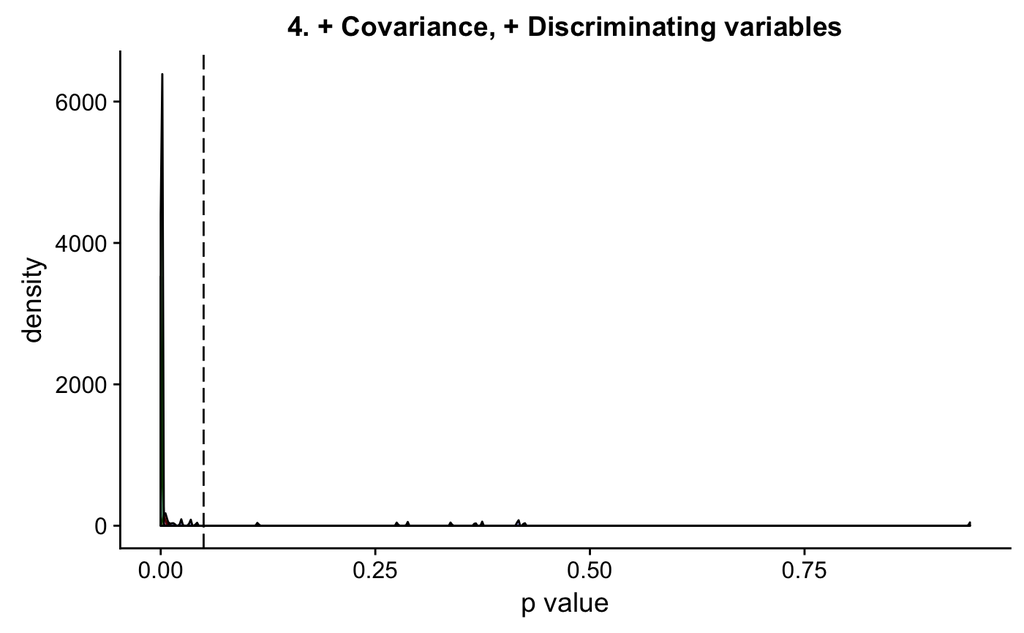

```r
data4.comparison <- full_join(data4.PCAresults, data4.PLSresults) %>% add_column("permanova" = data4.permanova)
p4.perm <- ggplot(data4.comparison) +
  geom_density(aes(PC1.p.value), fill = "blue", alpha = 0.33) +
  geom_density(aes(pQ2), fill = "red", alpha = 0.33) +
  geom_density(aes(permanova), fill = "green", alpha = 0.33) +
  labs(x = "p value") +
  geom_vline(xintercept = 0.05, linetype = 5) +
  ggtitle("4. + Covariance, + Discriminating variables")
p4.perm
```

# Plot example datasets

```r
plots <- plot_grid(p1,p2,p3,p4, ncol = 1, nrow = 4)
save_plot("figs/fig1.png", plots, ncol = 2, nrow = 4, base_aspect_ratio = 1, base_height = 3.5)
```

# Plot permutation testing results

```r
plots.perm <- plot_grid(p1.perm, p2.perm, p3.perm, p4.perm, ncol = 2, nrow = 2)
```

```
Removed 1 rows containing non-finite values (stat_density).
```

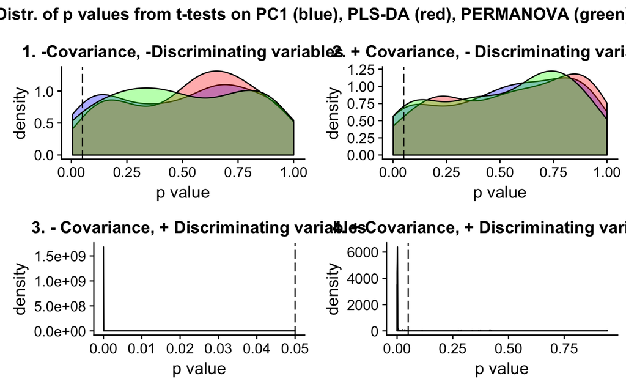

```r
p.val_figure <- plot_grid(ggplot() + ggtitle("Distr. of p values from t-tests on PC1 (blue), PLS-DA (red), PERMANOVA (green)"), plots.perm, ncol = 1, rel_heights = c(0.1, 1))
p.val_figure
save_plot("figs/fig2.png", p.val_figure, ncol = 2, nrow = 2, base_aspect_ratio = 1.5)
```

# Conclusions

None of the methods give more false positives than they should—that is, no differences are found when there are no discriminating variables.

# Trying alternate method of making discriminating variables

I can’t even figure out how to make PLS-DA find a difference.

```r
sim.data5 <- sim.vcov(p_noise = 0,
                      p_signal = 15,
                      p_disc = 15,
                      cov_signal = 0.8,
                      cov_disc = 0.6,
                      diff_disc = 0,
                      var = 0.8,
                      N = 20,
                      seed = NA)
sim.data5 <- sim.data5 %>%
  rename(Y = disc_1) %>%
  arrange(Y) %>%
  mutate(group = c(rep("a", nrow(.)/2), rep("b", nrow(.)/2)))
```

```
PCA
20 samples x 29 variables
standard scaling of predictors
      R2X(cum) pre ort
Total    0.882   2   0
```

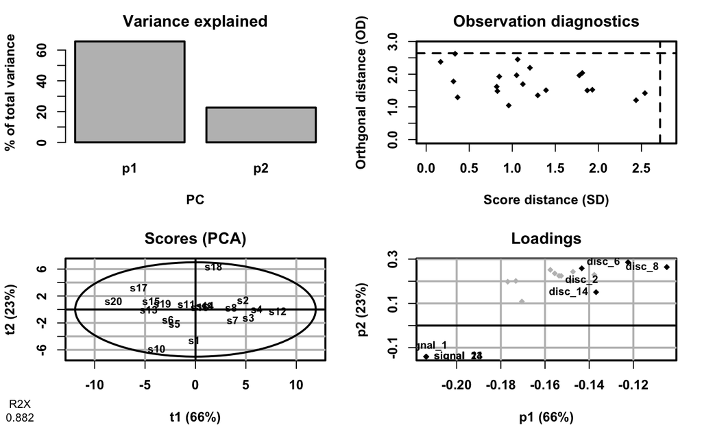

```r
pca5 <- opls(select(sim.data5, -Y, -group), predI = 2)
```

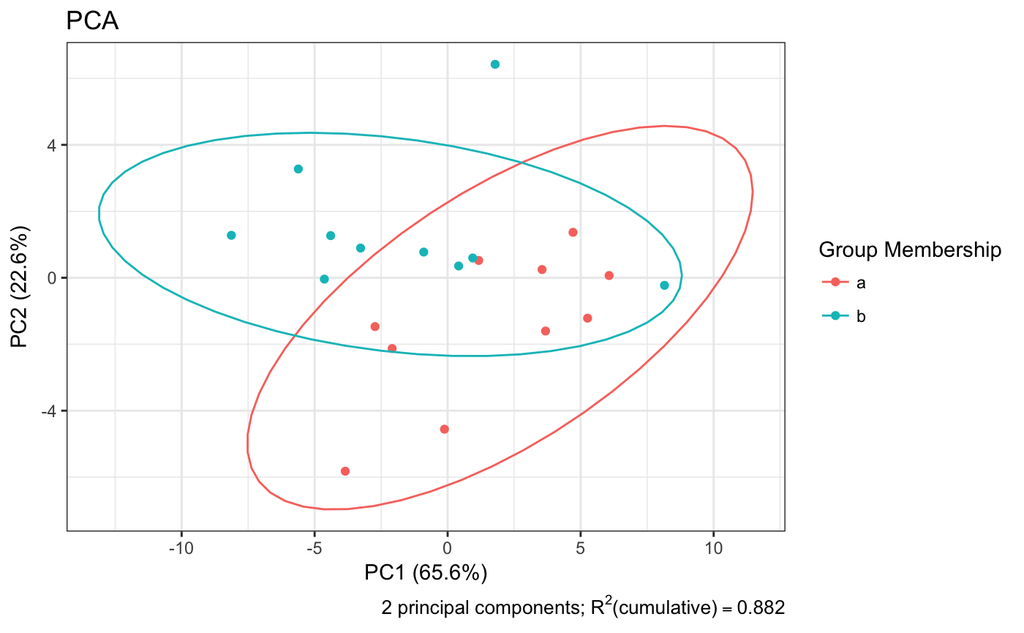

```r
pca_plot(pca5, sim.data5$group)
```

```
PLS-DA
20 samples x 29 variables and 1 response
standard scaling of predictors and response(s)
      R2X(cum) R2Y(cum) Q2(cum) RMSEE pre ort pR2Y   pQ2
Total    0.882    0.507   0.327 0.381   2   0 0.08 0.025
```

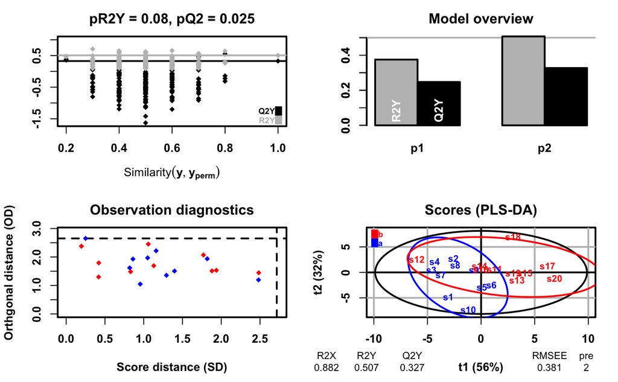

```r
plsda5 <- opls(select(sim.data5, -group, -Y), sim.data5$group, permI = 200, predI = 2)
```

```r
get_VIP(plsda5) %>% arrange(desc(VIP))
```

| Variable | VIP |
| --- | --- |
| disc_5 | 1.5511423 |
| disc_13 | 1.5476641 |
| disc_2 | 1.3969209 |
| disc_6 | 1.3789184 |
| disc_11 | 1.3487526 |
| disc_9 | 1.2881609 |
| disc_15 | 1.2449292 |
| disc_12 | 1.2147622 |
| disc_10 | 1.1365559 |
| disc_4 | 1.0938769 |

[output cut: 19 more lines]

```
PLS
20 samples x 29 variables and 1 response
standard scaling of predictors and response(s)
      R2X(cum) R2Y(cum) Q2(cum) RMSEE pre ort pR2Y   pQ2
Total     0.88     0.64   0.471 0.498   2   0 0.02 0.005
```

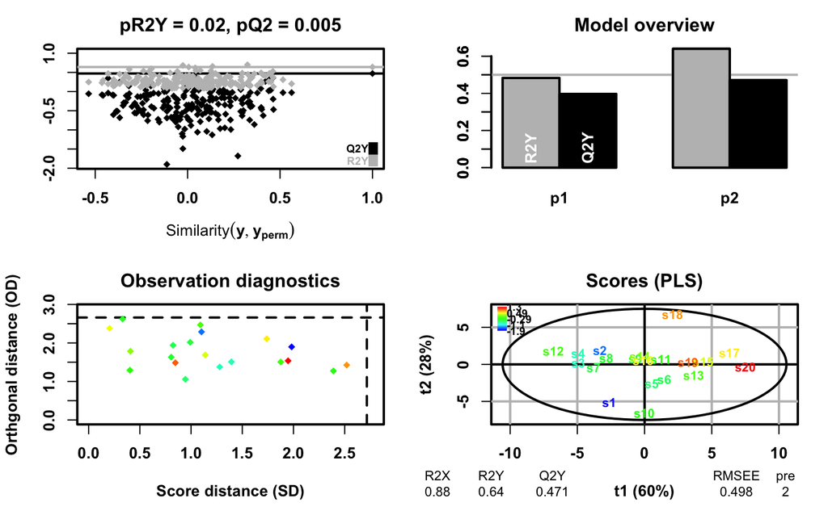

```r
pls5 <- opls(select(sim.data5, -group, -Y), sim.data5$Y, permI = 200, predI = 2)
```

Huh, that doesn’t work

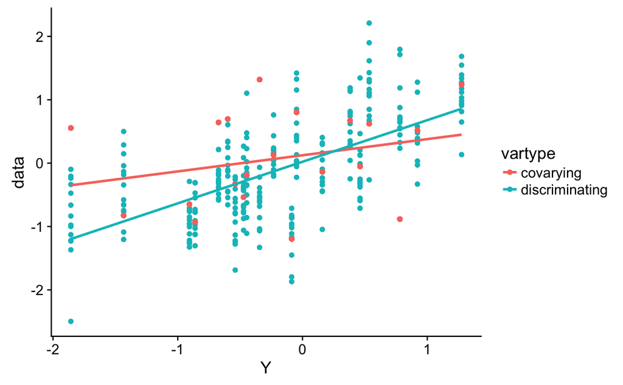

```r
plotdata <- sim.data5 %>%
  gather(-group, -Y, key = variable, value = data) %>%
  mutate(vartype = case_when(str_detect(variable, "disc") ~ "discriminating",
                             str_detect(variable, "noise") ~ "no covariance",
                             str_detect(variable, "signal") ~ "covarying"))
ggplot(plotdata, aes(x = Y, y = data, color = vartype)) +
  geom_point() +
  geom_smooth(method ="lm", se = FALSE)
```

*Ah ha! Is it because the discriminating data actually does NOT co-vary?* No, I upped the covariance and it doesn’t help.

Permanova

```r
permdata5 <- sim.data5 %>%
  # select(-Y) %>%
  mutate_if(is.double, scale)
adonis(select(permdata5, -group, -Y)~permdata5$group*permdata5$Y, method = "eu")
```

```
Call:
adonis(formula = select(permdata5, -group, -Y) ~ permdata5$group *      permdata5$Y, method = "eu")

Permutation: free
Number of permutations: 999

Terms added sequentially (first to last)

                            Df SumsOfSqs MeanSqs F.Model      R2 Pr(>F)
permdata5$group              1     93.01  93.015  3.8219 0.16881  0.027 *
permdata5$Y                  1     54.00  53.997  2.2187 0.09800  0.104
permdata5$group:permdata5$Y  1     14.59  14.587  0.5994 0.02647  0.546
Residuals                   16    389.40  24.338         0.70672
Total                       19    551.00                 1.00000
---
Signif. codes:  0 ‘***’ 0.001 ‘**’ 0.01 ‘*’ 0.05 ‘.’ 0.1 ‘ ’ 1
```